# D24 · Рекомендации: ALS и маленькие системы Холецкого

**Связь со слайдом:** «ALS: много небольших обновлений вместо одной огромной задачи», D24. Сначала повторим его таблицу `u1…u3 × i1…i4`, затем построим работающую модель рекомендаций курсов.

**Результат демо:** увидим одно обновление вектора пользователя, разложение его матрицы $2\times2$, чередование фаз ALS, прогнозы неизвестных оценок и проверку на отложенных наблюдениях. Все данные синтетические; это воспроизводимая демонстрация вычислений, не оценка качества промышленного рекомендателя.

**Запуск:** выберите Python-ядро общего окружения из README и выполните **Restart Kernel → Run All**. Нужны `numpy`, `scipy`, `pandas`, `matplotlib`, `IPython`; загрузок из сети, GPU и обучения нейросетей нет. Небольшие системы решаются на CPU. Если нужны отдельные PNG/CSV/JSON, включите `SAVE_OUTPUTS` в следующей ячейке.

```python
from pathlib import Path
import importlib.metadata
import json
import os
import platform
import sys
import time

import numpy as np
import pandas as pd
import matplotlib.pyplot as plt
from matplotlib.patches import Rectangle
from scipy.linalg import cho_factor, cho_solve, solve_triangular
from IPython.display import display

SEED = 42
RANK = 3
LAMBDA = 0.10                 # коэффициент именно у суммы квадратов факторов
N_EPOCHS = 35                 # фиксируем до просмотра test
SAVE_OUTPUTS = False
OUTPUT_DIR = Path("outputs/d24")

np.set_printoptions(precision=4, suppress=True)
plt.rcParams.update({"figure.dpi": 110, "font.size": 11, "axes.spines.top": False,
                     "axes.spines.right": False})
COLORS = {"blue": "#276FBF", "orange": "#D97706", "gray": "#687787"}
started_at = time.perf_counter()

environment = {
    "seed": SEED, "python": sys.version.split()[0],
    "platform": platform.platform(), "machine": platform.machine(),
    "processor": platform.processor() or "не указан ОС", "cpu_count": os.cpu_count(),
    "device": "CPU", "dtype": "float64",
    "packages": {name: importlib.metadata.version(name)
                 for name in ("numpy", "scipy", "pandas", "matplotlib")},
}
display(pd.Series(environment, name="Параметры запуска").to_frame())


def maybe_save_figure(fig, name):
    if SAVE_OUTPUTS:
        OUTPUT_DIR.mkdir(parents=True, exist_ok=True)
        fig.savefig(OUTPUT_DIR / name, dpi=160, bbox_inches="tight")
```

|  | Параметры запуска |
| --- | --- |
| seed | 42 |
| python | 3.12.14 |
| platform | macOS-26.6.2-arm64-arm-64bit |
| machine | arm64 |
| processor | arm |
| cpu_count | 10 |
| device | CPU |
| dtype | float64 |
| packages | {'numpy': '2.5.3', 'scipy': '1.18.1', 'pandas'... |

## 1. Восстанавливаем смысл таблицы со слайда

На слайде единица — **факт наблюдения**, а пустая ячейка — отсутствие наблюдения. Здесь в точности те же шесть связей: `u1 → i1, i3`, `u2 → i2, i4`, `u3 → i1, i4`.

Для численного примера добавим на эти связи **учебные явные оценки** от 1 до 5. Слева — исходная маска взаимодействий, справа — придуманные рейтинги. Рейтинг отсутствует — храним `NaN`, а не измеренный ноль. Это explicit-feedback ALS: в ошибку входят только наблюдённые оценки. Позже отдельно обсудим отличие от implicit feedback.

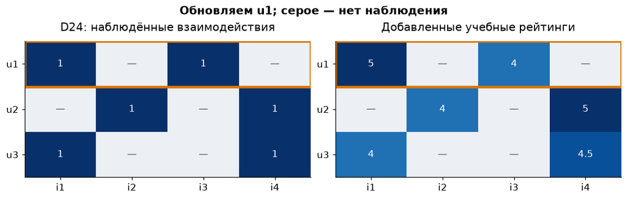

```python
user_ids = ["u1", "u2", "u3"]
item_ids = ["i1", "i2", "i3", "i4"]
toy_mask = np.array([[True, False, True, False],
                     [False, True, False, True],
                     [True, False, False, True]])
toy_ratings = np.array([[5.0, np.nan, 4.0, np.nan],
                        [np.nan, 4.0, np.nan, 5.0],
                        [4.0, np.nan, np.nan, 4.5]])
assert np.array_equal(np.isfinite(toy_ratings), toy_mask)
assert toy_mask.sum() == 6


def plot_masked_matrix(ax, values, title, row_labels, col_labels, vmin, vmax,
                       annotate=False, selected_row=None):
    cmap = plt.colormaps["Blues"].copy()
    cmap.set_bad("#ECEFF3")
    im = ax.imshow(np.ma.masked_invalid(values), cmap=cmap, vmin=vmin, vmax=vmax,
                   aspect="auto")
    ax.set_title(title, pad=12)
    ax.set_xticks(np.arange(len(col_labels)), col_labels)
    ax.set_yticks(np.arange(len(row_labels)), row_labels)
    if annotate:
        for u, i in np.ndindex(values.shape):
            label = f"{values[u, i]:g}" if np.isfinite(values[u, i]) else "—"
            color = "white" if np.isfinite(values[u, i]) and values[u, i] > (vmin + vmax) / 2 else "#253243"
            ax.text(i, u, label, ha="center", va="center", color=color)
    if selected_row is not None:
        ax.add_patch(Rectangle((-0.5, selected_row - 0.5), values.shape[1], 1,
                               fill=False, lw=3, edgecolor=COLORS["orange"]))
    return im


fig, axes = plt.subplots(1, 2, figsize=(10, 3.1), constrained_layout=True)
plot_masked_matrix(axes[0], np.where(toy_mask, 1.0, np.nan),
                   "D24: наблюдённые взаимодействия", user_ids, item_ids, 0, 1, True, 0)
plot_masked_matrix(axes[1], toy_ratings, "Добавленные учебные рейтинги", user_ids,
                   item_ids, 1, 5, True, 0)
fig.suptitle("Обновляем u1; серое — нет наблюдения", fontweight="bold")
maybe_save_figure(fig, "01_toy_observations.png")
plt.show()
```

## 2. Одно обновление: зафиксировать объекты и решить ridge-задачу

Для факторов пользователей $P\in\mathbb R^{n_u\times k}$ и объектов $Q\in\mathbb R^{n_i\times k}$ оптимизируем

$$J(P,Q)=\sum_{(u,i)\in\Omega}(r_{ui}-p_u^\top q_i)^2+ \lambda\left(\|P\|_F^2+\|Q\|_F^2\right),\qquad \lambda>0.$$

Когда $Q$ зафиксирована, строка $p_u$ зависит только от рейтингов пользователя $u$. Пусть $B=Q_{\Omega_u}$ — строки факторов наблюдённых объектов. Тогда

$$A_u p_u=b_u,\qquad A_u=B^\top B+\lambda I_k,\qquad b_u=B^\top r_u.$$

$z^\top A_u z=\|Bz\|^2+\lambda\|z\|^2>0$ для ненулевого $z$, поэтому матрица положительно определена. Разложим **малую** матрицу $A_u=LL^\top$ и выполним два треугольных решения. Обратная матрица не нужна; размер системы — число факторов $k$, а не число всех взаимодействий.

[`scipy.linalg.cho_factor`](https://docs.scipy.org/doc/scipy/reference/generated/scipy.linalg.cho_factor.html) строит факторизацию, [`cho_solve`](https://docs.scipy.org/doc/scipy/reference/generated/scipy.linalg.cho_solve.html) использует её для решения.

```python
def ridge_update(B, ratings, lam):
    """Одно точное регуляризованное обновление, включая отсутствие наблюдений."""
    B = np.asarray(B, dtype=np.float64)
    ratings = np.asarray(ratings, dtype=np.float64)
    if not np.isfinite(lam) or lam <= 0:
        raise ValueError("lambda должна быть конечной и строго положительной")
    if B.ndim != 2 or ratings.shape != (B.shape[0],):
        raise ValueError("Ожидаются B: (n_observed, k), ratings: (n_observed,)")
    if B.shape[1] == 0 or not np.isfinite(B).all() or not np.isfinite(ratings).all():
        raise ValueError("Нужны конечные значения и хотя бы один фактор")
    A = B.T @ B + lam * np.eye(B.shape[1])
    b = B.T @ ratings
    factor = cho_factor(A, lower=True)
    solution = cho_solve(factor, b)
    # Берём только нижний треугольник: второй треугольник не является частью L.
    L = np.tril(factor[0])
    return solution, A, b, L


def objective_parts(R, P, Q, lam):
    observed = np.isfinite(R)
    residual = R[observed] - (P @ Q.T)[observed]
    squared_error = float(residual @ residual)
    regularizer = float(lam * (np.sum(P ** 2) + np.sum(Q ** 2)))
    return squared_error, regularizer


def objective(R, P, Q, lam):
    return sum(objective_parts(R, P, Q, lam))


toy_rng = np.random.default_rng(SEED)
P_before = toy_rng.normal(scale=0.3, size=(3, 2))
Q_fixed = np.array([[1.0, 0.2], [0.2, 1.0], [0.9, 0.5], [0.4, 1.1]])
Q_copy = Q_fixed.copy()
selected_user = 0
observed_items = np.flatnonzero(toy_mask[selected_user])
B = Q_fixed[observed_items]
r = toy_ratings[selected_user, observed_items]
toy_lambda = 0.3
p_new, A, b, L = ridge_update(B, r, toy_lambda)
P_after = P_before.copy()
P_after[selected_user] = p_new

print(f"u1: объекты {[item_ids[i] for i in observed_items]}, оценки {r}")
print(f"B: {B.shape}, A: {A.shape}, b: {b.shape}, p: {p_new.shape}")
for name, matrix in {"B = строки Q для i1 и i3": B, "A = BᵀB + λI": A,
                     "L (A = LLᵀ)": L}.items():
    print(name)
    display(pd.DataFrame(matrix, columns=["координата 1", "координата 2"]))
display(pd.DataFrame({"b": b, "p до": P_before[0], "p после": p_new},
                     index=["координата 1", "координата 2"]))
```

```
u1: объекты ['i1', 'i3'], оценки [5. 4.]
B: (2, 2), A: (2, 2), b: (2,), p: (2,)
B = строки Q для i1 и i3
```

|  | координата 1 | координата 2 |
| --- | --- | --- |
| 0 | 1.0 | 0.2 |
| 1 | 0.9 | 0.5 |

```
A = BᵀB + λI
```

|  | координата 1 | координата 2 |
| --- | --- | --- |
| 0 | 2.11 | 0.65 |
| 1 | 0.65 | 0.59 |

```
L (A = LLᵀ)
```

|  | координата 1 | координата 2 |
| --- | --- | --- |
| 0 | 1.452584 | 0.00000 |
| 1 | 0.447478 | 0.62431 |

|  | b | p до | p после |
| --- | --- | --- | --- |
| координата 1 | 8.6 | 0.091415 | 3.798638 |
| координата 2 | 3.0 | -0.311995 | 0.899805 |

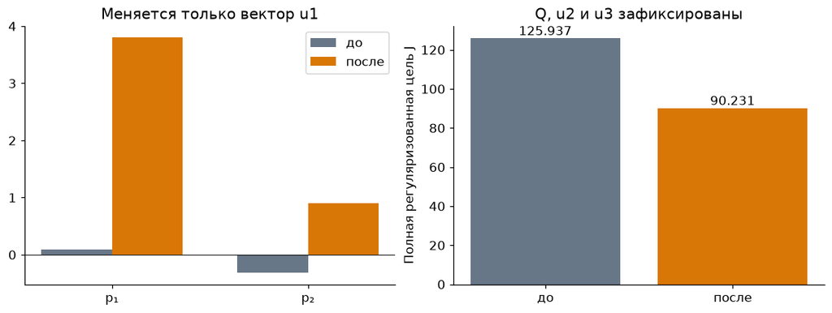

```
Проверено: LLᵀ=A; Ap=b; менялась только строка u1; J не выросла.
```

```python
loss_before = objective(toy_ratings, P_before, Q_fixed, toy_lambda)
loss_after = objective(toy_ratings, P_after, Q_fixed, toy_lambda)
np.testing.assert_allclose(L @ L.T, A, atol=1e-12)
np.testing.assert_allclose(A @ p_new, b, atol=1e-12)
np.testing.assert_array_equal(Q_fixed, Q_copy)
np.testing.assert_array_equal(P_after[1:], P_before[1:])
assert loss_after <= loss_before + 1e-12

fig, axes = plt.subplots(1, 2, figsize=(10, 3.7), constrained_layout=True)
coords = np.arange(2)
axes[0].bar(coords - 0.18, P_before[0], width=0.36, color=COLORS["gray"], label="до")
axes[0].bar(coords + 0.18, P_after[0], width=0.36, color=COLORS["orange"], label="после")
axes[0].set_xticks(coords, ["p₁", "p₂"])
axes[0].set_title("Меняется только вектор u1")
axes[0].axhline(0, color="black", lw=0.6)
axes[0].legend()
axes[1].bar(["до", "после"], [loss_before, loss_after],
            color=[COLORS["gray"], COLORS["orange"]])
axes[1].set_ylabel("Полная регуляризованная цель J")
axes[1].set_title("Q, u2 и u3 зафиксированы")
for j, value in enumerate([loss_before, loss_after]):
    axes[1].text(j, value, f"{value:.3f}", ha="center", va="bottom")
maybe_save_figure(fig, "02_single_user_update.png")
plt.show()
print("Проверено: LLᵀ=A; Ap=b; менялась только строка u1; J не выросла.")
```

### Та же локальная задача через QR

Регуляризацию можно включить дополнительными строками:

$$\min_p\left\|\begin{bmatrix}B\\ \sqrt\lambda I\end{bmatrix}p- \begin{bmatrix}r\\0\end{bmatrix}\right\|^2.$$

QR и Холецкий решают здесь одну задачу; на этом хорошо обусловленном примере результаты совпадут с точностью округления. QR работает с расширенной матрицей напрямую. Формирование $B^\top B$ может ухудшить обусловленность; это одна из причин, почему Холецкий не является обязательным определением ALS.

```python
B_aug = np.vstack([B, np.sqrt(toy_lambda) * np.eye(B.shape[1])])
r_aug = np.concatenate([r, np.zeros(B.shape[1])])
Q_qr, R_qr = np.linalg.qr(B_aug, mode="reduced")
p_qr = solve_triangular(R_qr, Q_qr.T @ r_aug)
np.testing.assert_allclose(p_qr, p_new, rtol=1e-11, atol=1e-12)
print(f"||p_QR - p_Холецкий||₂ = {np.linalg.norm(p_qr - p_new):.3e}")
print(f"cond(B_aug)={np.linalg.cond(B_aug):.3f}; cond(A)={np.linalg.cond(A):.3f}")

# Без рейтингов минимум λ||p||² достигается в нуле.
cold_start, _, _, _ = ridge_update(np.empty((0, 2)), np.empty(0), toy_lambda)
np.testing.assert_array_equal(cold_start, np.zeros(2))
for invalid_lambda in (0.0, -1.0, np.nan):
    try:
        ridge_update(B, r, invalid_lambda)
    except ValueError:
        pass
    else:
        raise AssertionError("Недопустимая регуляризация должна быть отклонена")
print("Проверено: QR ≈ Холецкий; cold start даёт нулевой фактор; λ > 0.")
```

```
||p_QR - p_Холецкий||₂ = 6.661e-16
cond(B_aug)=2.591; cond(A)=6.715
Проверено: QR ≈ Холецкий; cold start даёт нулевой фактор; λ > 0.
```

## 3. От маленькой схемы к прогнозированию рейтингов курсов

У 60 вымышленных студентов есть скрытые предпочтения по трём направлениям, у 40 вымышленных курсов — три признака. Генератор создаёт непрерывный рейтинг $r_{ui}=3+0.65\,p_u^\top q_i+\varepsilon_{ui}$, где $\varepsilon\sim\mathcal N(0,0.04^2)$. Это искусственный пример, согласованный с низкоранговой моделью; факторам нельзя приписывать смысл без дополнительного анализа.

Для каждого студента случайно выбираем **20 train-оценок и 6 test-оценок**. Остальные пары вообще не наблюдались. Разбиение фиксируется один раз. Среднее, факторы и baseline оцениваются только по train. Test используется один раз в финальном сравнении; ранг, регуляризация и число эпох уже заданы выше.

```
Train: 1200 оценок; test: 360; нет наблюдений: 840
Среднее только train: 2.9946; диапазон train: [1.74, 4.10]
```

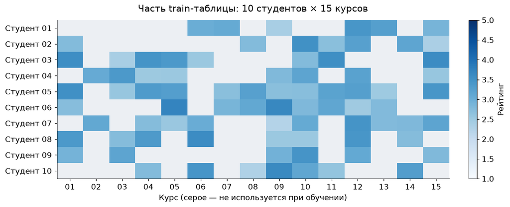

```python
def make_synthetic_split(seed, n_users=60, n_items=40, latent_rank=3):
    rng = np.random.default_rng(seed)
    hidden_users = rng.uniform(-1, 1, (n_users, latent_rank))
    hidden_items = rng.uniform(-1, 1, (n_items, latent_rank))
    complete_scores = 3.0 + 0.65 * hidden_users @ hidden_items.T
    complete_scores += rng.normal(0, 0.04, complete_scores.shape)
    train = np.full((n_users, n_items), np.nan)
    test_u, test_i = [], []
    for u in range(n_users):
        shuffled = rng.permutation(n_items)
        train_items, test_items = shuffled[:20], shuffled[20:26]
        train[u, train_items] = complete_scores[u, train_items]
        test_u.extend([u] * len(test_items))
        test_i.extend(test_items)
    test_u, test_i = np.array(test_u), np.array(test_i)
    test_y = complete_scores[test_u, test_i].copy()
    # Не возвращаем скрытые факторы или заполненную таблицу обучающему коду.
    return train, test_u, test_i, test_y


train_ratings, test_users, test_items, test_ratings = make_synthetic_split(SEED)
train_mask = np.isfinite(train_ratings)
test_mask = np.zeros_like(train_mask)
test_mask[test_users, test_items] = True
assert not np.any(train_mask & test_mask)
assert (train_mask.sum(axis=1) == 20).all()
assert (test_mask.sum(axis=1) == 6).all()
assert (train_mask.sum(axis=0) > 0).all()       # у каждого курса есть train

train_mean = float(np.nanmean(train_ratings))
centered_train = train_ratings - train_mean   # NaN остаются NaN
student_names = [f"Студент {u + 1:02d}" for u in range(train_ratings.shape[0])]
course_names = [f"Курс {i + 1:02d}" for i in range(train_ratings.shape[1])]
print(f"Train: {train_mask.sum()} оценок; test: {test_mask.sum()}; "
      f"нет наблюдений: {(~(train_mask | test_mask)).sum()}")
print(f"Среднее только train: {train_mean:.4f}; "
      f"диапазон train: [{np.nanmin(train_ratings):.2f}, {np.nanmax(train_ratings):.2f}]")

fig, ax = plt.subplots(figsize=(10, 4), constrained_layout=True)
image = plot_masked_matrix(ax, train_ratings[:10, :15],
                           "Часть train-таблицы: 10 студентов × 15 курсов",
                           student_names[:10], [f"{i+1:02d}" for i in range(15)], 1, 5)
ax.set_xlabel("Курс (серое — не используется при обучении)")
fig.colorbar(image, ax=ax, label="Рейтинг")
maybe_save_figure(fig, "03_train_matrix.png")
plt.show()
```

## 4. Полный ALS: пользователи → объекты → повторить

В большой модели используем $\hat r_{ui}=\mu_{train}+p_u^\top q_i$. Среднее $\mu_{train}$ вычисляется заранее и фиксируется, поэтому ALS обучается на центрированных оценках. Регуляризация остаётся $\lambda(\|P\|_F^2+\|Q\|_F^2)$ — **без умножения на число оценок** пользователя или объекта.

В пользовательской фазе все строки $P$ обновляются при фиксированной $Q$; в следующей фазе все строки $Q$ — при фиксированной новой $P$. После **каждой** фазы проверяем, что полная цель $J$ не выросла. Убывание train-цели не гарантирует убывания test-ошибки или достижения глобального минимума совместной задачи.

```python
def fit_als(centered_R, rank, lam, n_epochs, seed):
    observed = np.isfinite(centered_R)
    if not observed.any():
        raise ValueError("Нужно хотя бы одно train-наблюдение")
    if rank < 1 or n_epochs < 1 or not np.isfinite(lam) or lam <= 0:
        raise ValueError("Требуются rank >= 1, n_epochs >= 1, lambda > 0")
    rng = np.random.default_rng(seed)
    P = rng.normal(0, 0.2, (centered_R.shape[0], rank))
    Q = rng.normal(0, 0.2, (centered_R.shape[1], rank))
    users_to_items = [np.flatnonzero(row) for row in observed]
    items_to_users = [np.flatnonzero(col) for col in observed.T]
    history = []

    def record(epoch, phase):
        squared_error, penalty = objective_parts(centered_R, P, Q, lam)
        total = squared_error + penalty
        if history:
            previous = history[-1]["objective"]
            assert total <= previous + 1e-9 * max(1.0, previous), (phase, previous, total)
        history.append({"epoch": epoch, "phase": phase, "objective": total,
                        "squared_error": squared_error, "regularizer": penalty,
                        "train_rmse": np.sqrt(squared_error / observed.sum())})

    record(0, "initial")
    for epoch in range(1, n_epochs + 1):
        for u, items in enumerate(users_to_items):
            P[u], _, _, _ = ridge_update(Q[items], centered_R[u, items], lam)
        record(epoch, "users")
        for i, users in enumerate(items_to_users):
            Q[i], _, _, _ = ridge_update(P[users], centered_R[users, i], lam)
        record(epoch, "items")
    return P, Q, pd.DataFrame(history)


fit_start = time.perf_counter()
P, Q, history = fit_als(centered_train, RANK, LAMBDA, N_EPOCHS, SEED + 1)
fit_seconds = time.perf_counter() - fit_start
predicted_ratings = train_mean + P @ Q.T
assert np.isfinite(P).all() and np.isfinite(Q).all()
assert len(history) == 1 + 2 * N_EPOCHS

print(f"Размеры P={P.shape}, Q={Q.shape}; локальная система: {RANK}×{RANK}")
print(f"{N_EPOCHS} эпох, {2*N_EPOCHS} проверок убывания; обучение: {fit_seconds:.3f} с на CPU")
display(history.iloc[[0, 1, 2, 3, 4, -1]].round(6))
```

```
Размеры P=(60, 3), Q=(40, 3); локальная система: 3×3
35 эпох, 70 проверок убывания; обучение: 0.051 с на CPU
```

|  | epoch | phase | objective | squared_error | regularizer | train_rmse |
| --- | --- | --- | --- | --- | --- | --- |
| 0 | 0 | initial | 187.250919 | 186.022853 | 1.228066 | 0.393725 |
| 1 | 1 | users | 157.186853 | 153.536609 | 3.650244 | 0.357697 |
| 2 | 1 | items | 107.979578 | 103.413767 | 4.565811 | 0.293561 |
| 3 | 2 | users | 58.081257 | 51.995286 | 6.085971 | 0.208157 |
| 4 | 2 | items | 26.655955 | 19.955528 | 6.700427 | 0.128956 |
| 70 | 35 | items | 7.960178 | 1.573390 | 6.386789 | 0.036210 |

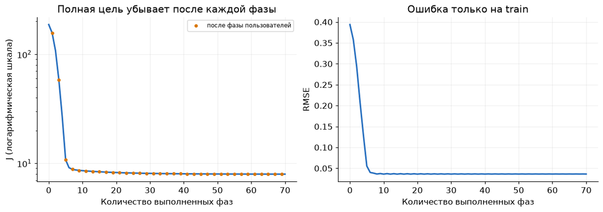

```python
fig, axes = plt.subplots(1, 2, figsize=(11, 3.8), constrained_layout=True)
phase_steps = np.arange(len(history))
axes[0].semilogy(phase_steps, history["objective"], color=COLORS["blue"], lw=2)
user_phase = history["phase"].eq("users")
axes[0].scatter(phase_steps[user_phase], history.loc[user_phase, "objective"],
                color=COLORS["orange"], s=12, label="после фазы пользователей", zorder=3)
axes[0].set(xlabel="Количество выполненных фаз", ylabel="J (логарифмическая шкала)",
            title="Полная цель убывает после каждой фазы")
axes[0].legend(fontsize=8)
axes[1].plot(phase_steps, history["train_rmse"], color=COLORS["blue"], lw=2)
axes[1].set(xlabel="Количество выполненных фаз", ylabel="RMSE", title="Ошибка только на train")
for ax in axes:
    ax.grid(alpha=0.2)
maybe_save_figure(fig, "04_als_convergence.png")
plt.show()
```

## 5. Проверка на test: с чем сравниваем

Две простые отправные точки: одно train-среднее и аддитивный baseline $\mu_{train}+b_u+b_i$. Во втором случае смещения обучаются только по train с фиксированной регуляризацией `5.0`. У ALS и baseline одинаковое разбиение, ни один метод не видел test-рейтинги. Все прогнозы остаются сырыми, без скрытого округления или обрезания к шкале.

RMSE проверяет численные рейтинги на известных отложенных парах. Эта величина не является метрикой качества списка рекомендаций и не подтверждает полезность реальному пользователю.

| Модель | train RMSE | test RMSE |
| --- | --- | --- |
| Среднее train | 0.3866 | 0.3764 |
| Среднее + смещения | 0.3762 | 0.3889 |
| ALS, k=3 | 0.0362 | 0.0481 |

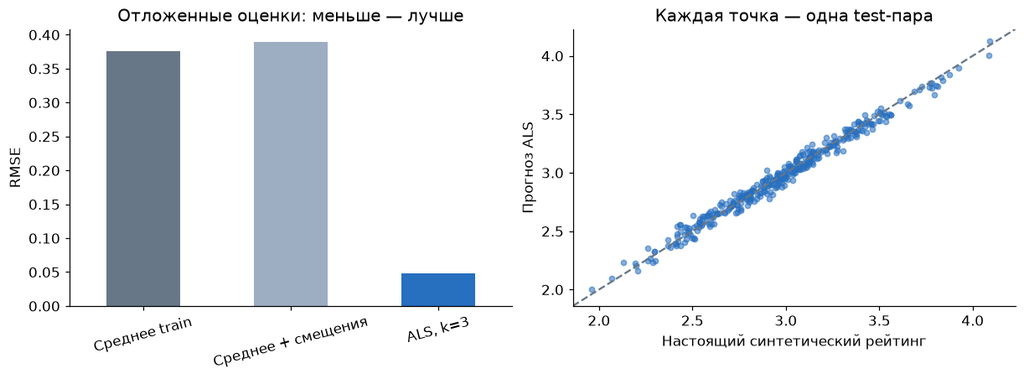

```python
def fit_bias_baseline(train, mean, lam=5.0, iterations=30):
    observed = np.isfinite(train)
    user_bias = np.zeros(train.shape[0])
    item_bias = np.zeros(train.shape[1])
    for _ in range(iterations):
        for u in range(train.shape[0]):
            items = np.flatnonzero(observed[u])
            user_bias[u] = np.sum(train[u, items] - mean - item_bias[items]) / (len(items) + lam)
        for i in range(train.shape[1]):
            users = np.flatnonzero(observed[:, i])
            item_bias[i] = np.sum(train[users, i] - mean - user_bias[users]) / (len(users) + lam)
    return mean + user_bias[:, None] + item_bias[None, :]


def rmse(actual, predicted):
    return float(np.sqrt(np.mean((actual - predicted) ** 2)))


bias_predictions = fit_bias_baseline(train_ratings, train_mean)
all_predictions = {
    "Среднее train": np.full(train_ratings.shape, train_mean),
    "Среднее + смещения": bias_predictions,
    f"ALS, k={RANK}": predicted_ratings,
}
# Финальная оценка: test не передавался в fit_als и fit_bias_baseline.
metrics = pd.DataFrame([
    {"Модель": name,
     "train RMSE": rmse(train_ratings[train_mask], prediction[train_mask]),
     "test RMSE": rmse(test_ratings, prediction[test_users, test_items])}
    for name, prediction in all_predictions.items()
]).set_index("Модель")
display(metrics.round(4))

fig, axes = plt.subplots(1, 2, figsize=(11, 4), constrained_layout=True)
metrics["test RMSE"].plot.bar(ax=axes[0], color=[COLORS["gray"], "#9DAEC2", COLORS["blue"]], rot=15)
axes[0].set(xlabel="", ylabel="RMSE", title="Отложенные оценки: меньше — лучше")
y_hat_test = predicted_ratings[test_users, test_items]
axes[1].scatter(test_ratings, y_hat_test, s=17, alpha=0.55, color=COLORS["blue"])
plot_low = min(test_ratings.min(), y_hat_test.min()) - 0.1
plot_high = max(test_ratings.max(), y_hat_test.max()) + 0.1
axes[1].plot([plot_low, plot_high], [plot_low, plot_high], "--", color=COLORS["gray"])
axes[1].set(xlabel="Настоящий синтетический рейтинг", ylabel="Прогноз ALS",
            title="Каждая точка — одна test-пара", xlim=(plot_low, plot_high), ylim=(plot_low, plot_high))
maybe_save_figure(fig, "05_heldout_quality.png")
plt.show()
```

## 6. Применение: список новых курсов для одного студента

Построим пять кандидатов для `Студент 01`. Исключаем **все уже наблюдённые** курсы этого студента: и train, и отложенные test-оценки. Значения test при ранжировании не используются. Оставшиеся курсы не имеют известного рейтинга в нашем наборе, поэтому показываем прогнозы без выдуманной оценки их качества.

Для нового пользователя без рейтингов локальное решение равно нулю: в центрированной модели все прогнозы будут равны $\mu_{train}$. Персонализация требует хотя бы каких-то данных или отдельной модели признаков.

```
Студент 01
```

| Место | Курс | Прогноз рейтинга | Известная оценка |
| --- | --- | --- | --- |
| 1 | Курс 39 | 3.575 | нет наблюдения |
| 2 | Курс 24 | 3.250 | нет наблюдения |
| 3 | Курс 10 | 3.207 | нет наблюдения |
| 4 | Курс 01 | 3.195 | нет наблюдения |
| 5 | Курс 03 | 3.190 | нет наблюдения |

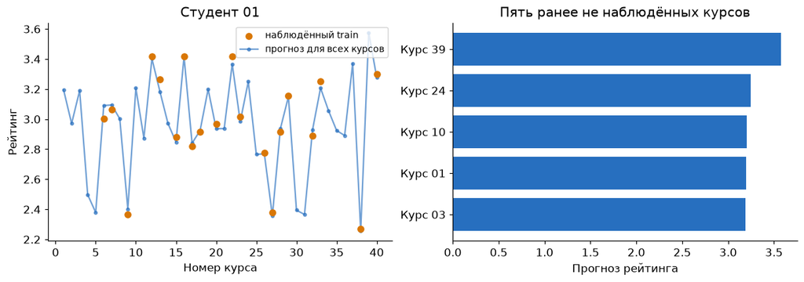

```python
chosen_student = 0
known_courses = train_mask[chosen_student] | test_mask[chosen_student]
candidate_ids = np.flatnonzero(~known_courses)
ranked_ids = candidate_ids[np.argsort(-predicted_ratings[chosen_student, candidate_ids], kind="stable")][:5]
assert not known_courses[ranked_ids].any()
recommendations = pd.DataFrame({
    "Курс": [course_names[i] for i in ranked_ids],
    "Прогноз рейтинга": predicted_ratings[chosen_student, ranked_ids],
    "Известная оценка": ["нет наблюдения"] * len(ranked_ids),
}, index=np.arange(1, len(ranked_ids) + 1))
recommendations.index.name = "Место"
print(student_names[chosen_student])
display(recommendations.round(3))

fig, axes = plt.subplots(1, 2, figsize=(11, 3.8), constrained_layout=True)
observed_course_ids = np.flatnonzero(train_mask[chosen_student])
axes[0].scatter(observed_course_ids + 1, train_ratings[chosen_student, observed_course_ids],
                label="наблюдённый train", color=COLORS["orange"], zorder=3)
axes[0].plot(np.arange(1, len(course_names) + 1), predicted_ratings[chosen_student],
             ".-", color=COLORS["blue"], alpha=0.65, label="прогноз для всех курсов")
axes[0].set(xlabel="Номер курса", ylabel="Рейтинг", title=student_names[chosen_student])
axes[0].legend(fontsize=9)
axes[1].barh(recommendations["Курс"][::-1], recommendations["Прогноз рейтинга"][::-1],
             color=COLORS["blue"])
axes[1].set(xlabel="Прогноз рейтинга", title="Пять ранее не наблюдённых курсов")
maybe_save_figure(fig, "06_recommendations.png")
plt.show()
```

## 7. Что связывает демо со слайдом D24

- Фиксированная сторона факторизации превращает обновление в небольшую задачу наименьших квадратов с регуляризацией. Затем стороны меняются ролями.
- При $\lambda>0$ локальная матрица SPD; её разложение Холецкого решает систему. В демо не факторизуется вся таблица рейтингов и не вычисляется обратная матрица.
- Мы проверили уменьшение полной train-цели после каждой фазы. Качество за пределами train проверяется отдельно.
- Пропуски исключены из explicit-feedback ошибки. Заменять их измеренными нулями означало бы изменить задачу.

**Отличие от ссылки `implicit` на слайде.** В библиотеке [`implicit.cpu.als.AlternatingLeastSquares`](https://benfred.github.io/implicit/api/models/cpu/als.html) используется модель *implicit feedback*: ненаблюдённым событиям назначают предпочтение и confidence согласно её функции потерь. Это не утверждение, что в исходных данных измерен рейтинг 0. В опубликованном CPU API `use_cg=True` по умолчанию; ALS может использовать CG вместо прямого решения через Холецкого. Наша реализация решает другую, явно записанную explicit-feedback цель.

**Вопросы для занятия:** зачем здесь $\lambda I$; почему неизвестный пользователь получает средний прогноз; почему убывание train-цели не обещает лучшего test; чем отличаются матрица наблюдений и заполненная матрица прогнозов? Чтобы экспериментировать с $k$ и $\lambda$ честно, добавьте отдельную validation-часть и оставьте test для финального отчёта.

**Первичные источники:** [SciPy: `cho_factor`](https://docs.scipy.org/doc/scipy/reference/generated/scipy.linalg.cho_factor.html), [SciPy: `cho_solve`](https://docs.scipy.org/doc/scipy/reference/generated/scipy.linalg.cho_solve.html), [документация implicit ALS](https://benfred.github.io/implicit/api/models/cpu/als.html). Ссылки проверены 2026-10-07.

```python
summary = {
    "slide": "D24", "seed": SEED, "data": "synthetic explicit ratings",
    "n_users": train_ratings.shape[0], "n_items": train_ratings.shape[1],
    "train_count": int(train_mask.sum()), "test_count": int(test_mask.sum()),
    "rank": RANK, "lambda": LAMBDA, "epochs": N_EPOCHS,
    "train_mean": train_mean, "als_fit_seconds": fit_seconds,
    "phase_checks": int(len(history) - 1),
    "max_objective_change": float(history["objective"].diff().dropna().max()),
    "qr_cholesky_difference": float(np.linalg.norm(p_qr - p_new)),
    "metrics": metrics.reset_index().to_dict(orient="records"),
    "environment": environment,
    "total_seconds": time.perf_counter() - started_at,
}
if SAVE_OUTPUTS:
    OUTPUT_DIR.mkdir(parents=True, exist_ok=True)
    history.to_csv(OUTPUT_DIR / "als_history.csv", index=False)
    metrics.to_csv(OUTPUT_DIR / "rmse.csv")
    recommendations.to_csv(OUTPUT_DIR / "recommendations.csv")
    (OUTPUT_DIR / "run_summary.json").write_text(
        json.dumps(summary, ensure_ascii=False, indent=2), encoding="utf-8")
    print(f"Артефакты сохранены: {OUTPUT_DIR.resolve()}")
else:
    print("Все результаты сохранены в выводах ноутбука; SAVE_OUTPUTS=False.")
print(f"Завершено: {summary['phase_checks']} проверок фаз, "
      f"test RMSE ALS = {metrics.loc[f'ALS, k={RANK}', 'test RMSE']:.4f}.")
```

```
Все результаты сохранены в выводах ноутбука; SAVE_OUTPUTS=False.
Завершено: 70 проверок фаз, test RMSE ALS = 0.0481.
```